# 《R语言》第12章：主题配色

[返回课程主页](https://psychbruce.github.io/RCourse/)

授课教师：包寒吴霜

版权声明：本套课程材料开源，使用和分享必须遵守「创作共用许可协议 CC BY-NC-SA」（来源引用-非商业用途使用-以相同方式共享）。

# Chap12：主题配色

#### 往期要点回顾

- [Chap11 # 分面小图](https://psychbruce.github.io/RCourse/Chap11#%E5%88%86%E9%9D%A2%E5%B0%8F%E5%9B%BE)
- [Chap11 # 多图组合](https://psychbruce.github.io/RCourse/Chap11#%E5%A4%9A%E5%9B%BE%E7%BB%84%E5%90%88)
- [Chap11 # 图形文件保存](https://psychbruce.github.io/RCourse/Chap11#%E5%9B%BE%E5%BD%A2%E6%96%87%E4%BB%B6%E4%BF%9D%E5%AD%98)

#### 本章要点目录

- 【实践1】配色方案设置（重点）
- 【实践2】主题元素设置

```r
## 本章所需R包
library(bruceR)
# library(ggplot2)  # 加载bruceR时已默认加载ggplot2
```

# 配色方案设置

主要认识两套经典调色板：Brewer和Viridis。

#### 【实践1】配色方案设置

- Brewer调色板（https://colorbrewer2.org/）
  - 分类色（Qualitative palettes）—— 适用于离散/分类/因子型变量
    - Accent, Dark2, Paired, Pastel1, Pastel2, **Set1 (常用)**, Set2, Set3
  - 对比色（Diverging palettes）—— 适用于连续/数值型变量
    - BrBG, PiYG, PRGn, PuOr, **RdBu (常用)**, RdGy, RdYlBu, RdYlGn, Spectral
  - 渐变色（Sequential palettes）—— 适用于连续/数值型变量
    - Blues, BuGn, BuPu, GnBu, Greens, Greys, Oranges, OrRd, PuBu, PuBuGn, PuRd, Purples, RdPu, Reds, YlGn, YlGnBu, YlOrBr, YlOrRd

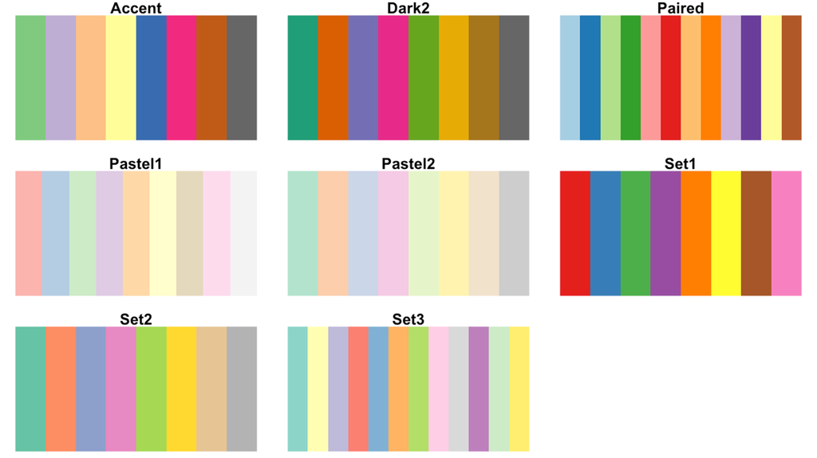

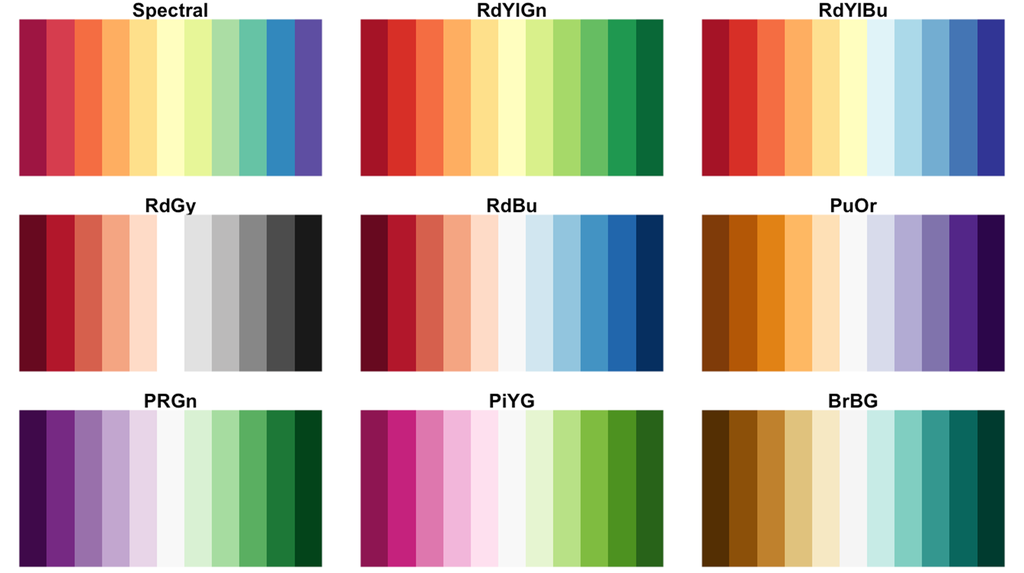

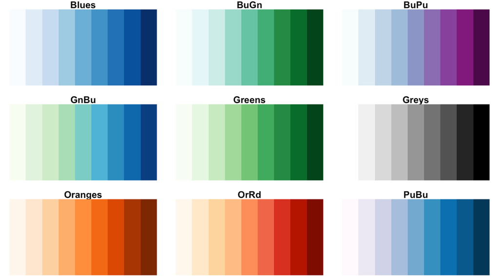

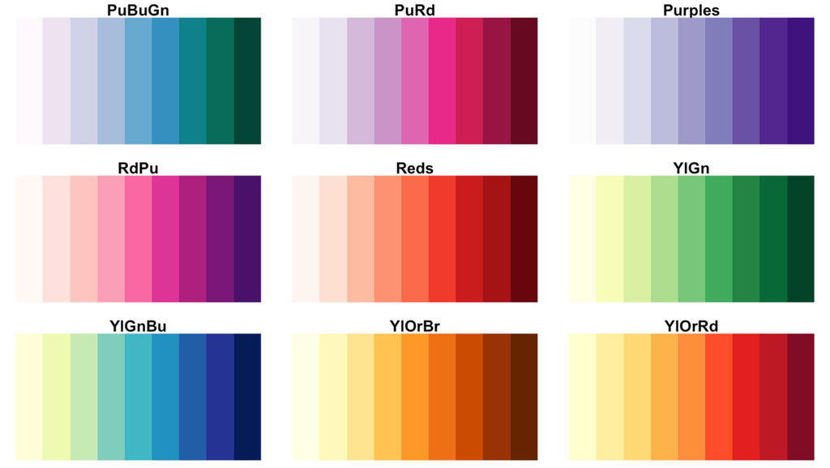

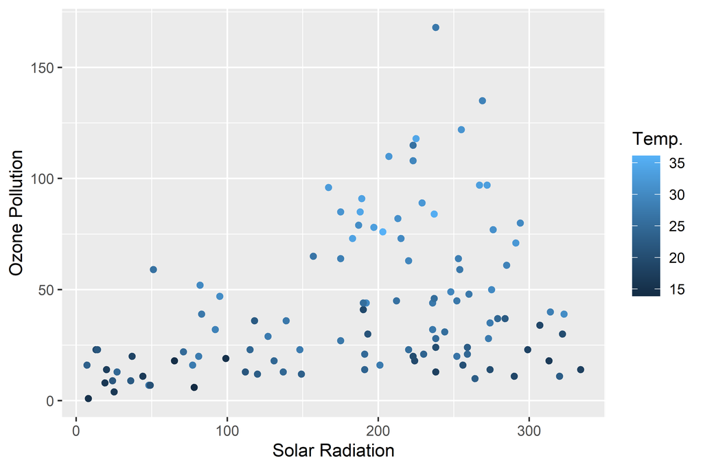

```r
## ggplot基础图形对象设定（赋值给p，避免重复写代码）
p = ggplot(
  data = na.omit(airquality),
  mapping = aes(x=Solar.R, y=Ozone, color=(Temp-32)/1.8)
)
p = p +
  geom_point() +
  labs(x="Solar Radiation",
       y="Ozone Pollution",
       color="Temp.")
p  # 默认配色
```

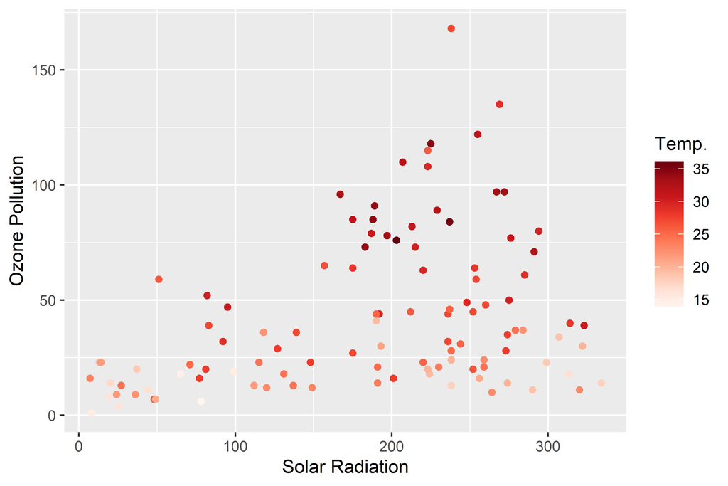

```r
p + scale_color_continuous(palette="Reds")
```

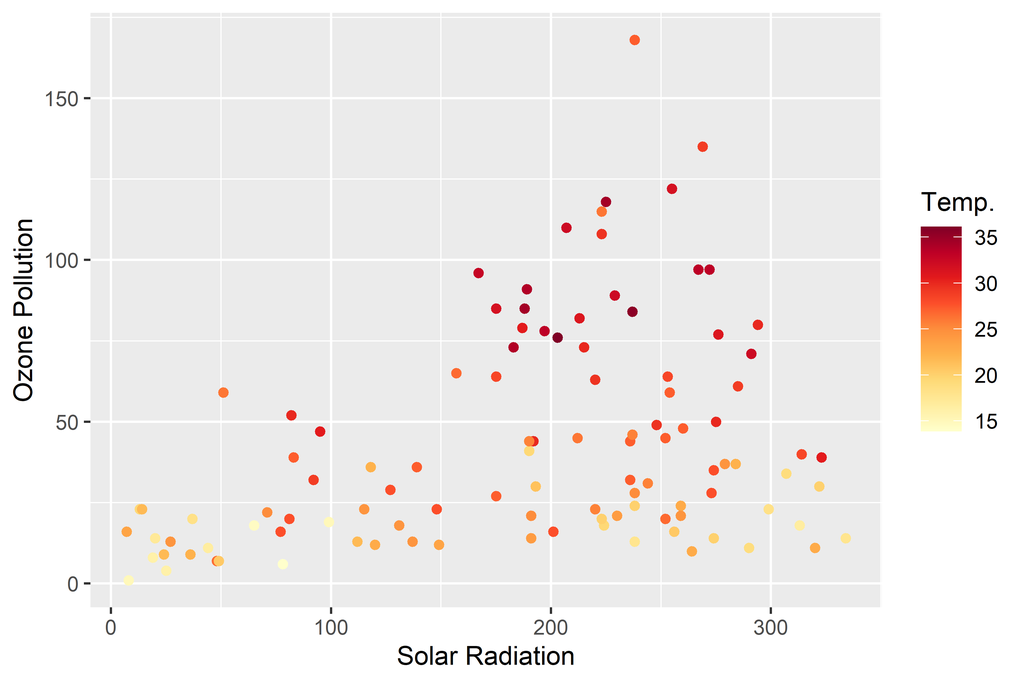

```r
p + scale_color_continuous(palette="YlOrRd")
```

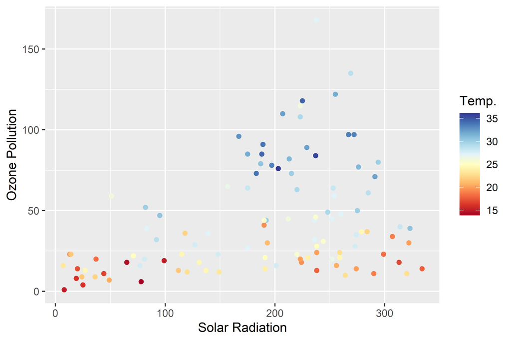

```r
p + scale_color_continuous(palette="RdYlBu")
```

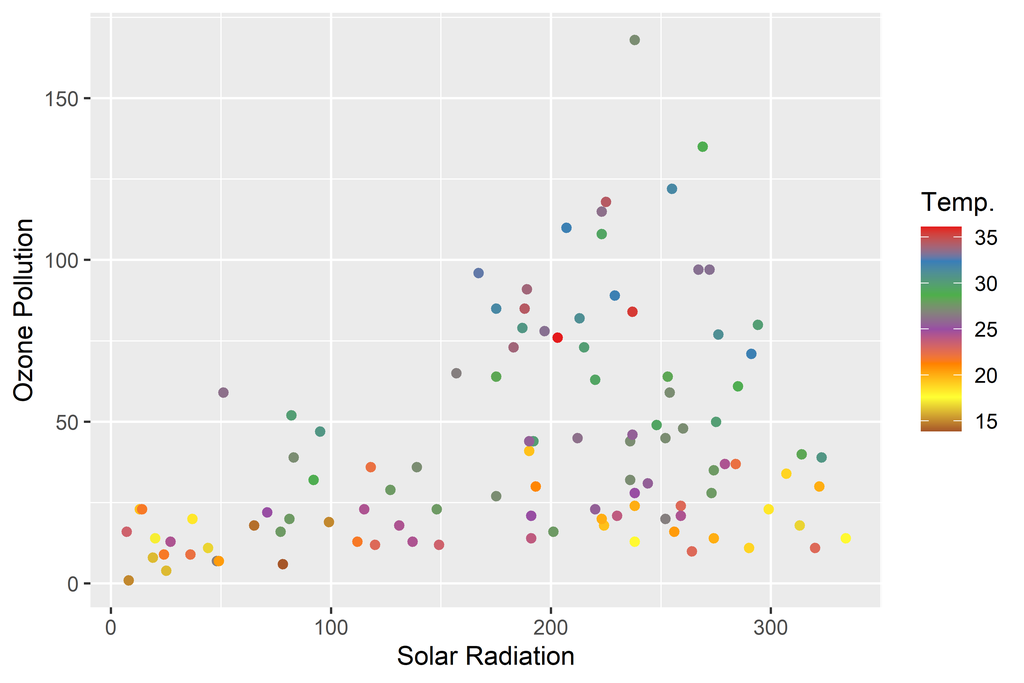

```r
## distiller：蒸馏器（离散颜色 => 连续颜色）
p + scale_color_distiller(palette="Set1", direction=-1)
```

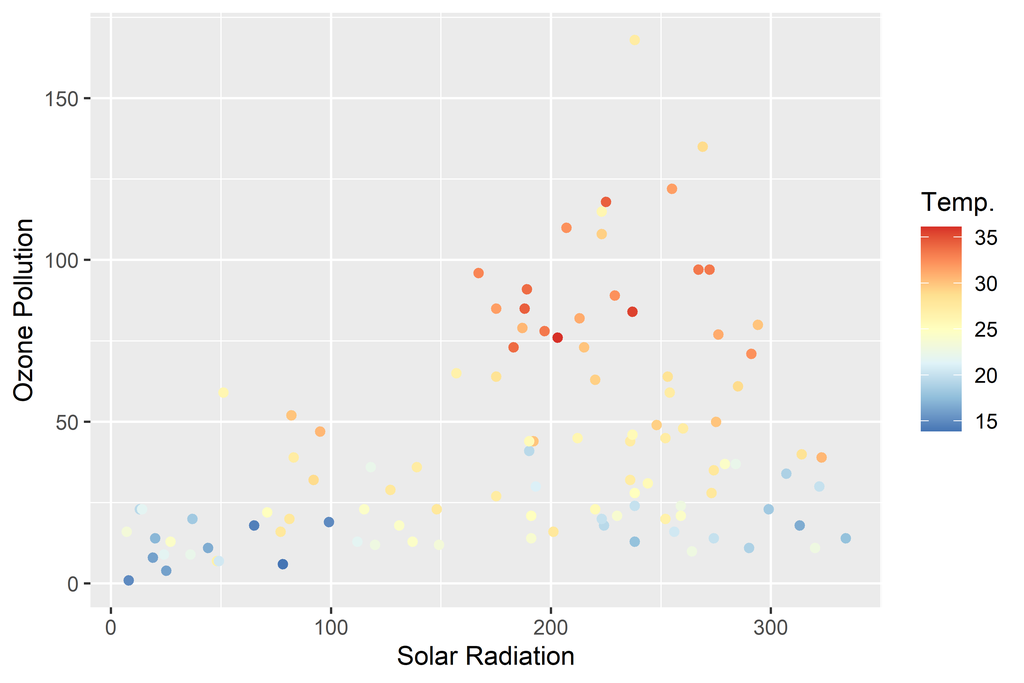

```r
p + scale_color_distiller(palette="RdYlBu", direction=-1)
```

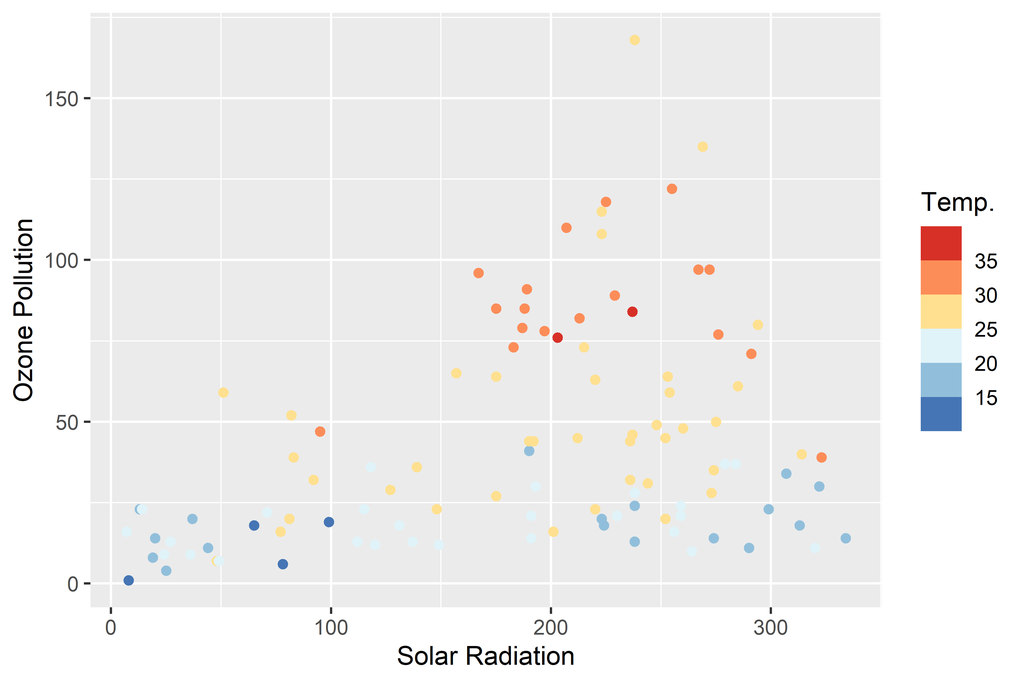

```r
## fermenter：发酵器（连续颜色 => 离散颜色）
p + scale_color_fermenter(palette="RdYlBu", direction=-1)
```

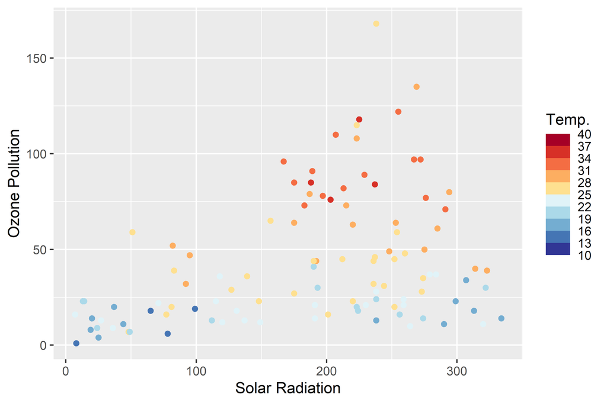

```r
p + scale_color_fermenter(palette = "RdYlBu",
                          direction = -1,
                          limits = c(10, 40),
                          breaks = seq(10, 40, 3))
```

- Viridis调色板
  - `"magma"` (or `"A"`)
  - `"inferno"` (or `"B"`)
  - `"plasma"` (or `"C"`)
  - `"viridis"` (or `"D"`)
  - `"cividis"` (or `"E"`)
  - `"rocket"` (or `"F"`)
  - `"mako"` (or `"G"`)
  - `"turbo"` (or `"H"`)

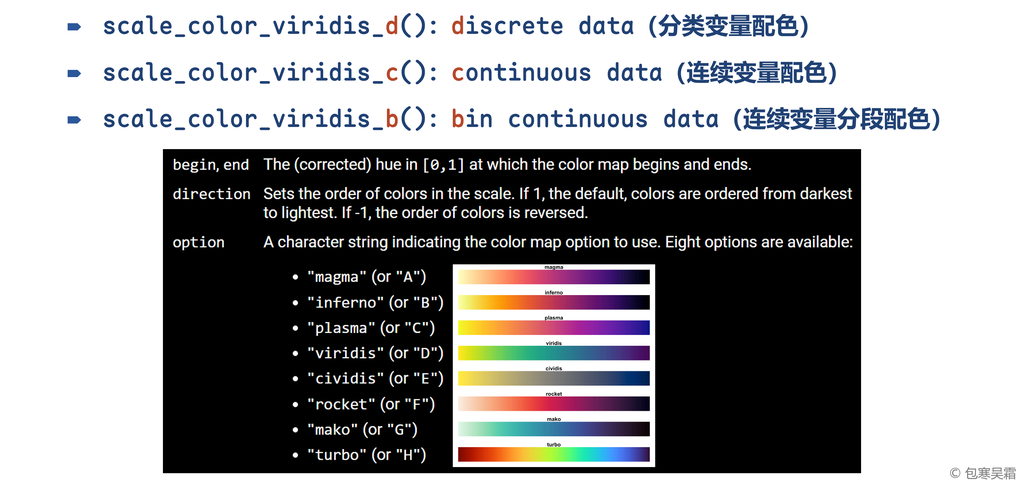

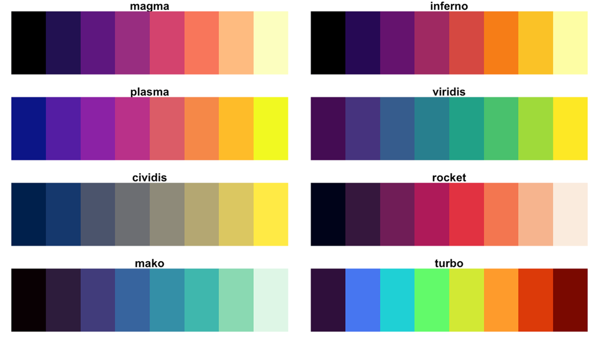

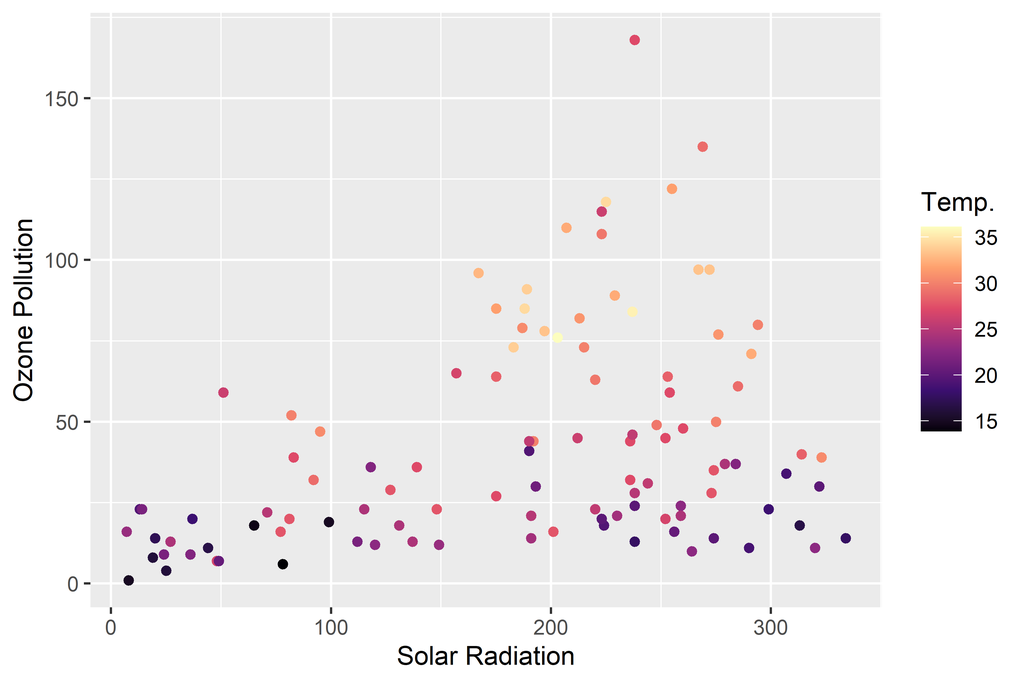

```r
p + scale_color_viridis_c(option="magma")  # "A"
```

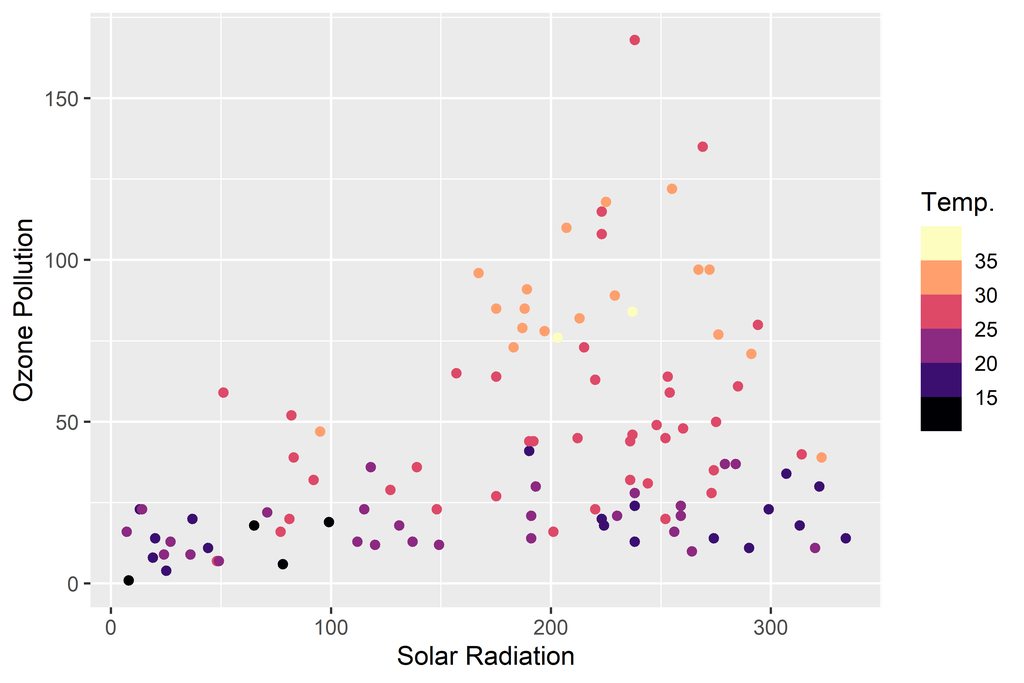

```r
p + scale_color_viridis_b(option="magma")  # "A"
```

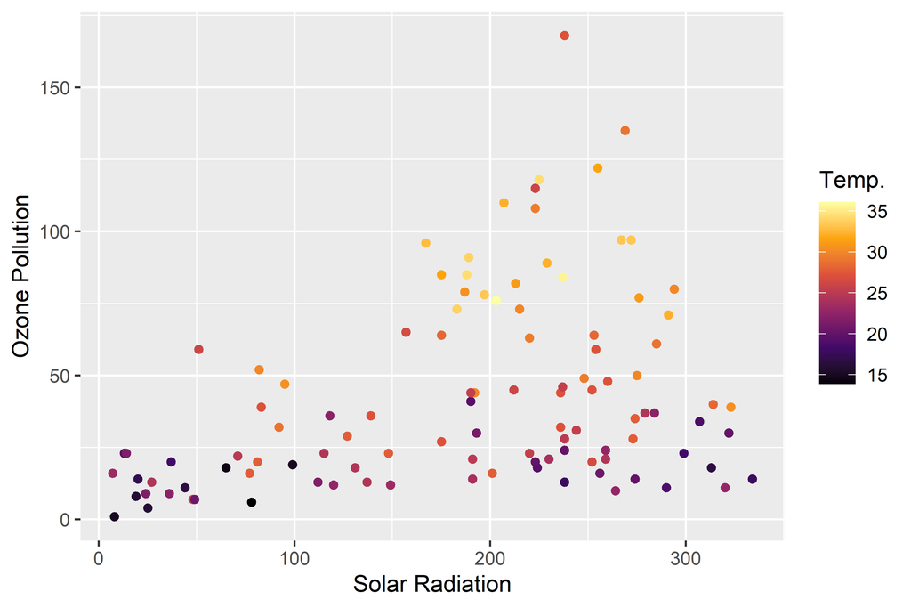

```r
p + scale_color_viridis_c(option="inferno")  # "B"
```

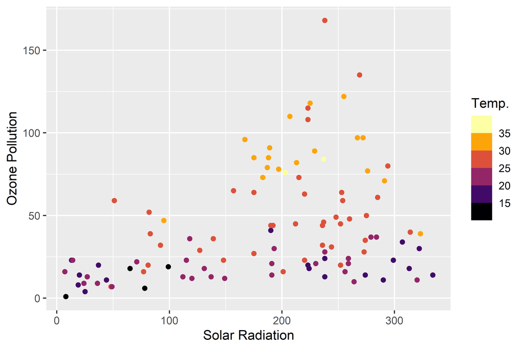

```r
p + scale_color_viridis_b(option="inferno")  # "B"
```

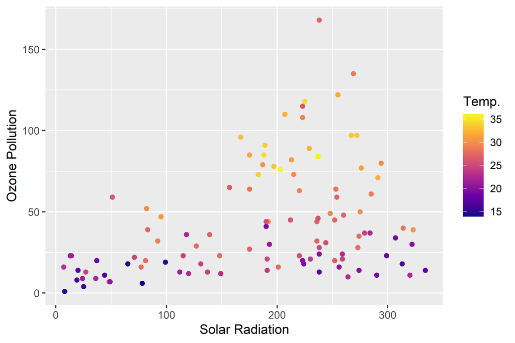

```r
p + scale_color_viridis_c(option="plasma")  # "C"
```

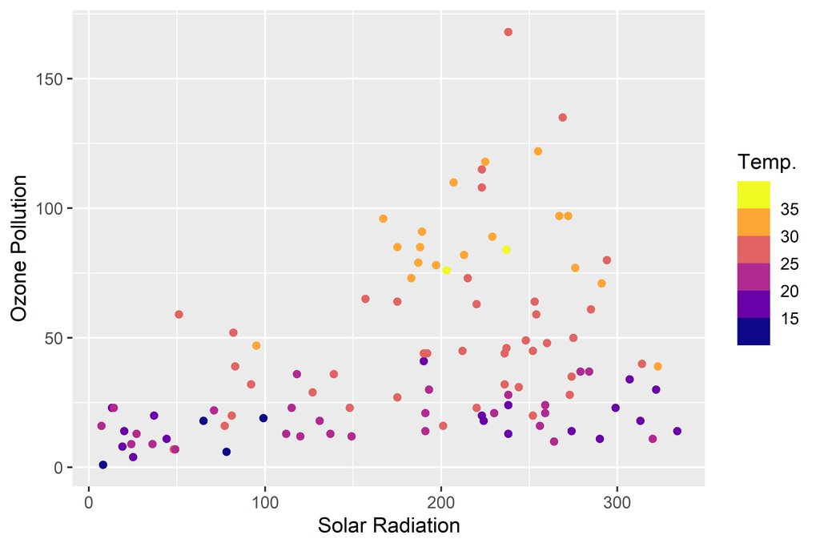

```r
p + scale_color_viridis_b(option="plasma")  # "C"
```

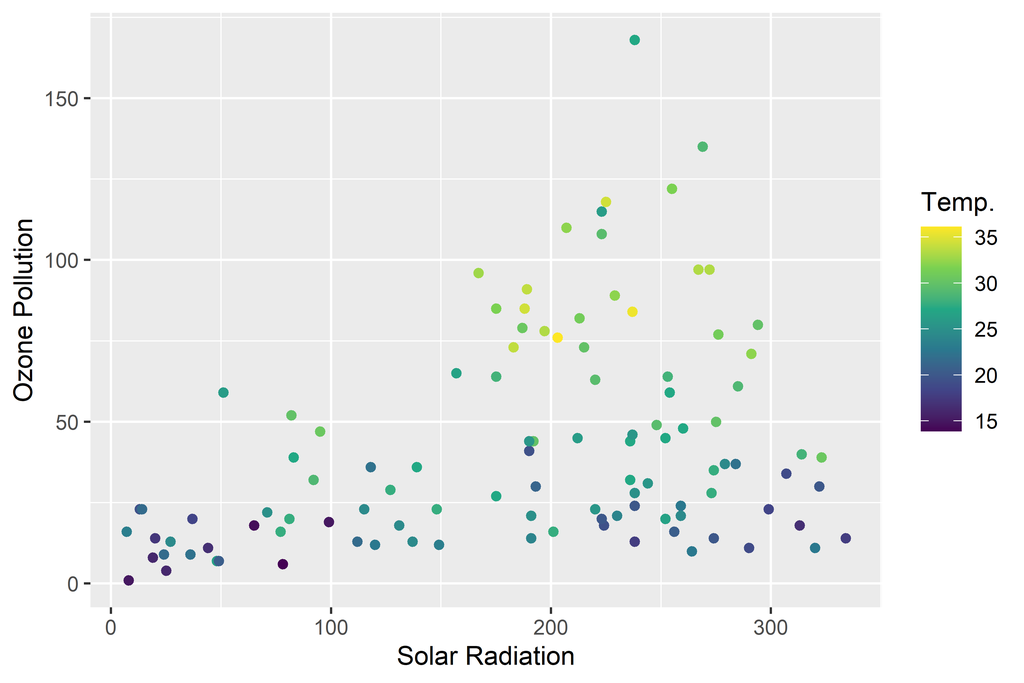

```r
p + scale_color_viridis_c(option="viridis")  # "D"
```

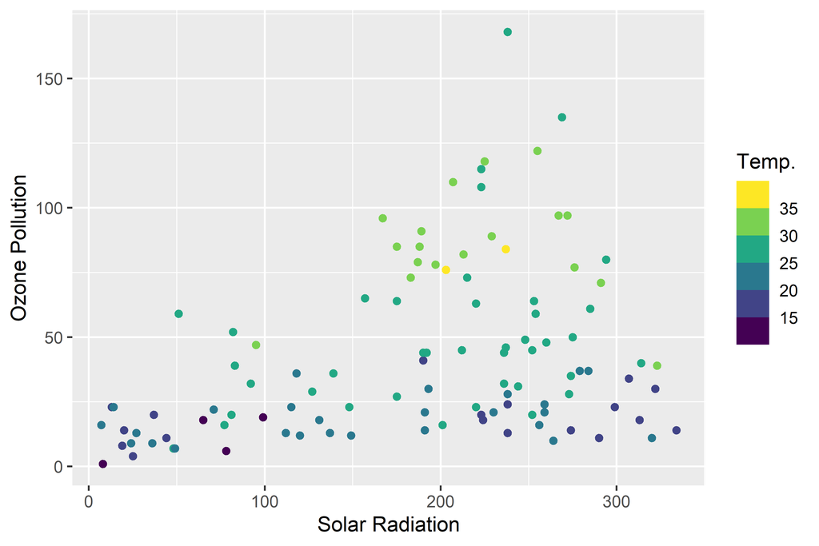

```r
p + scale_color_viridis_b(option="viridis")  # "D"
```

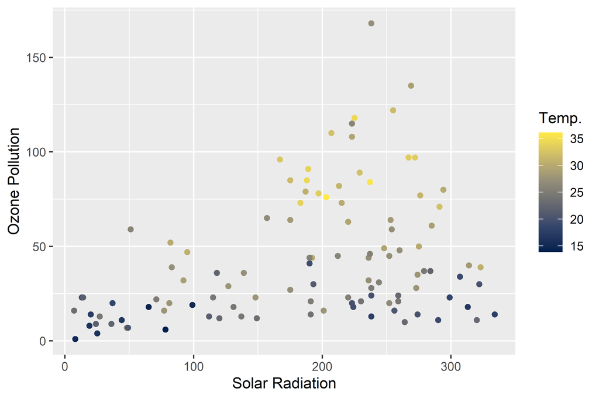

```r
p + scale_color_viridis_c(option="cividis")  # "E"
```

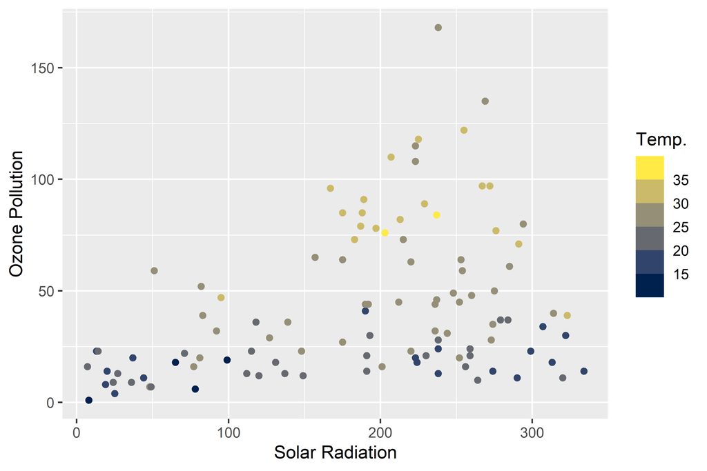

```r
p + scale_color_viridis_b(option="cividis")  # "E"
```

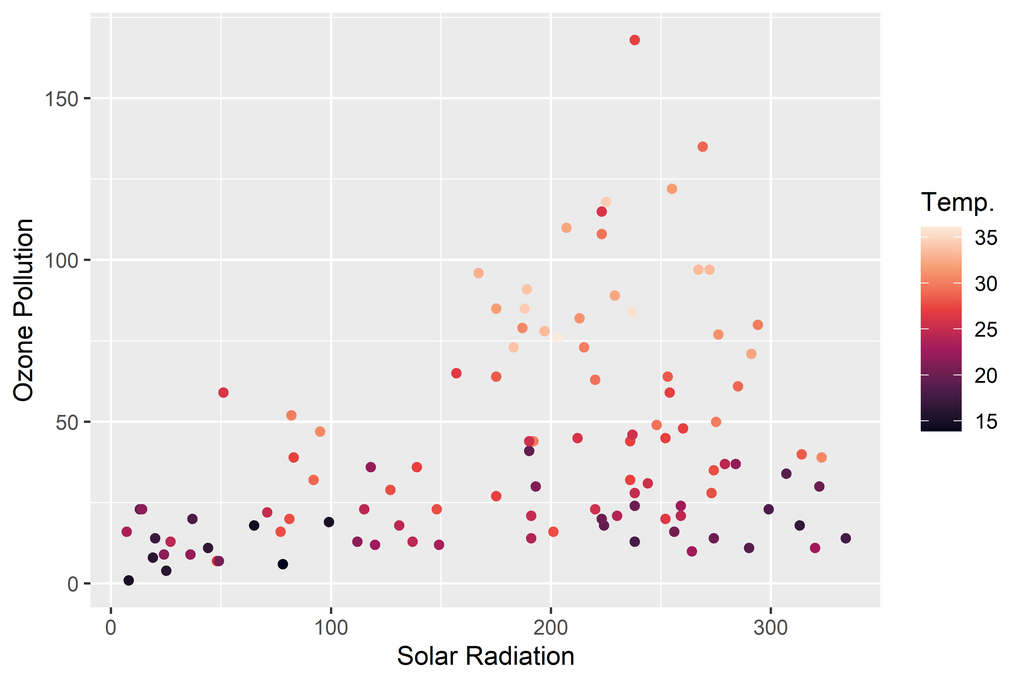

```r
p + scale_color_viridis_c(option="rocket")  # "F"
```

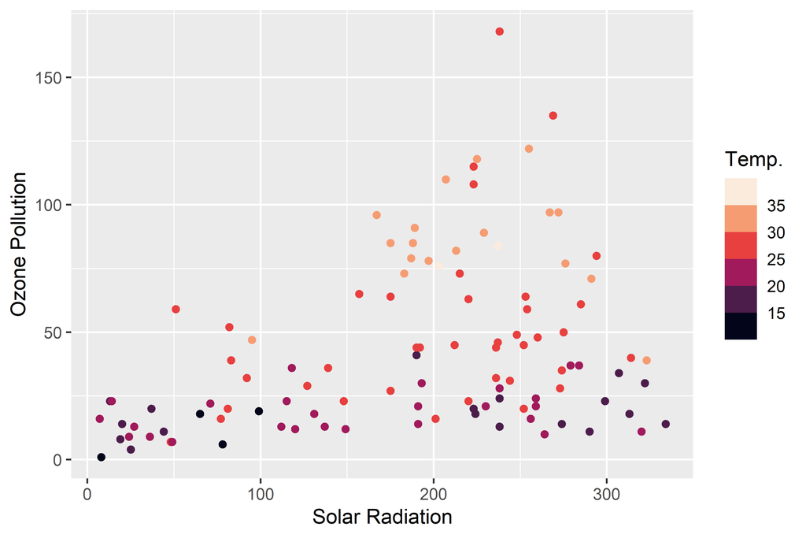

```r
p + scale_color_viridis_b(option="rocket")  # "F"
```

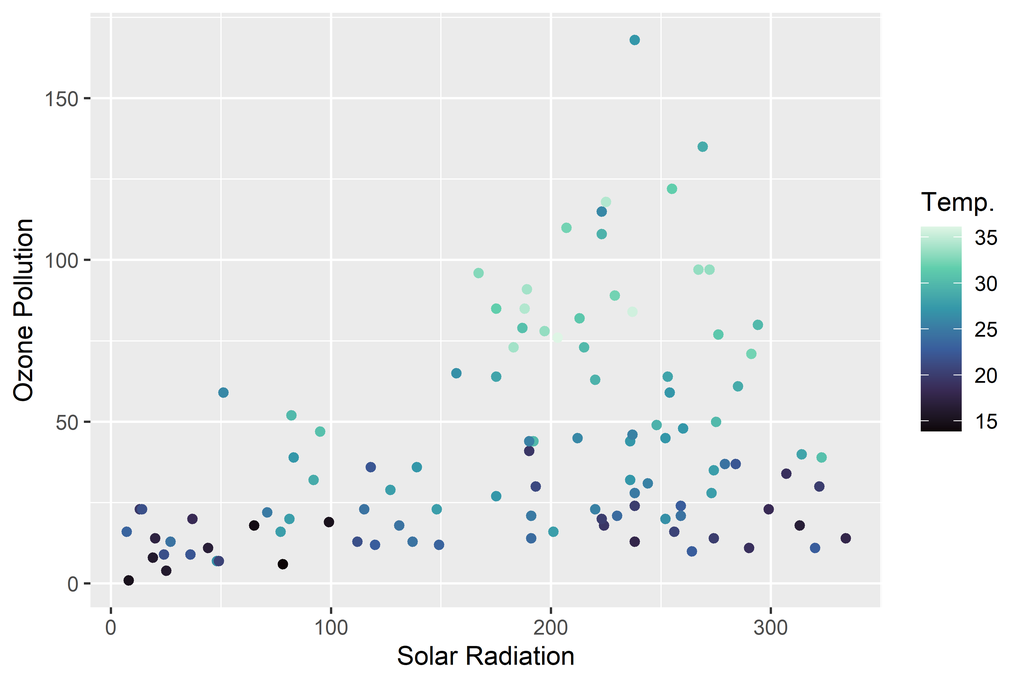

```r
p + scale_color_viridis_c(option="mako")  # "G"
```

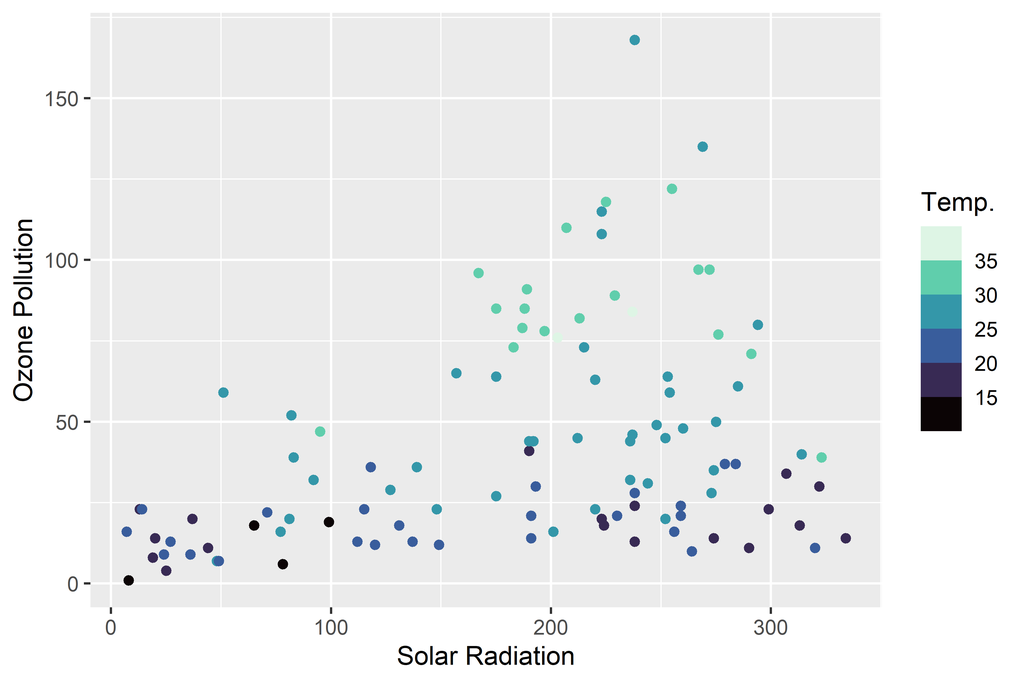

```r
p + scale_color_viridis_b(option="mako")  # "G"
```

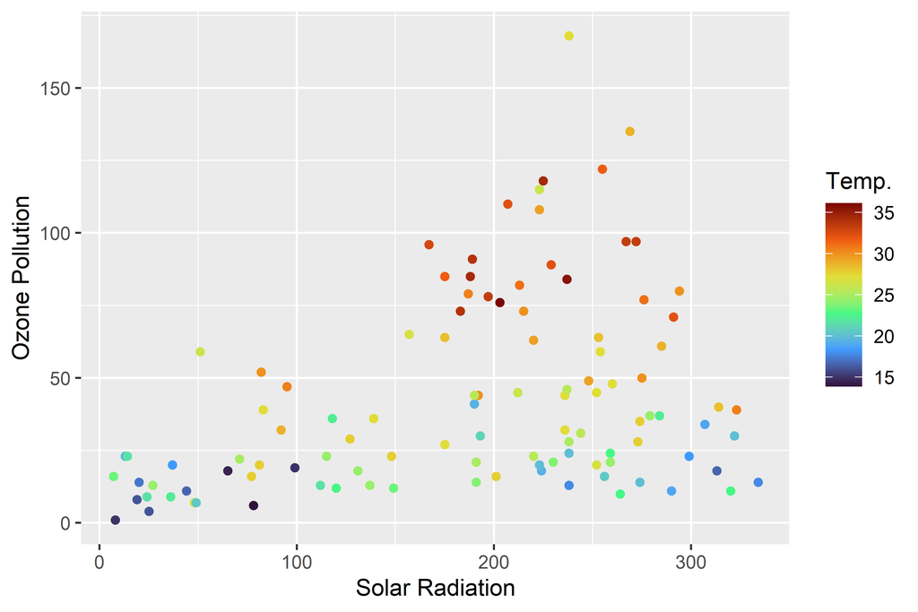

```r
p + scale_color_viridis_c(option="turbo")  # "H"
```

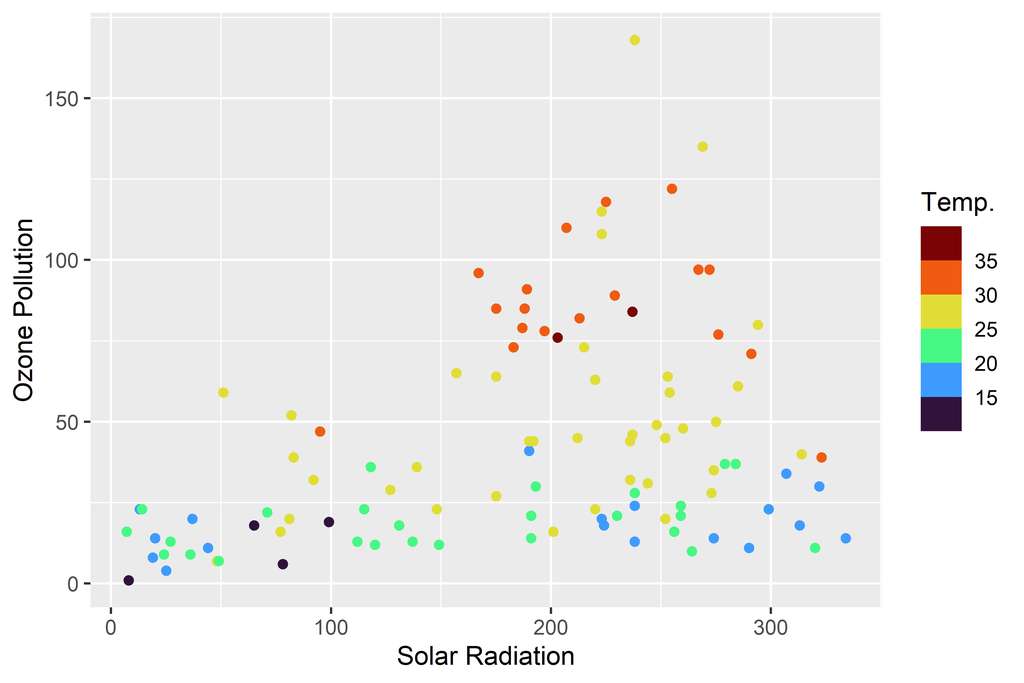

```r
p + scale_color_viridis_b(option="turbo")  # "H"
```